# Problem 1 — Building a Neural Network with PyTorch and Plotting the Training Accuracy

Template: *Chapter 10 – Building Neural Networks with PyTorch* (`10_neural_nets_with_pytorch.ipynb`).

The whole process (setup → data → model → training → **training accuracy plot** → evaluation → saving) was built incrementally with Claude Code as separate scripts in `scripts/`. Each script is placed below as one code cell, in executable order, and every cell is labeled with the script it came from.

| Cell | Generated script | Purpose |
| --- | --- | --- |
| 1 | `scripts/01_setup.py` | Setup |
| 2 | `scripts/02_load_data.py` | Load Fashion MNIST |
| 3 | `scripts/03_explore_data.py` | Explore the data |
| 4 | `scripts/04_build_model.py` | Build the MLP classifier |
| 5 | `scripts/05_train_utils.py` | Training and evaluation helpers |
| 6 | `scripts/06_train_model.py` | Train the model |
| 7 | `scripts/07_plot_training_accuracy.py` | Plot the training accuracy |
| 8 | `scripts/08_evaluate_and_predict.py` | Evaluate on the test set and predict |
| 9 | `scripts/09_save_model.py` | Save and reload the model |

## Cell 1 — Script `scripts/01_setup.py`: Setup

Based on the "Setup" section of the Chapter 10 template notebook (10_neural_nets_with_pytorch.ipynb).

```python
# ===== Script: scripts/01_setup.py =====
import sys
from pathlib import Path

assert sys.version_info >= (3, 10)

from packaging.version import Version
import numpy as np
import matplotlib
import matplotlib.pyplot as plt
import torch
import torch.nn as nn
import torchmetrics

assert Version(torch.__version__) >= Version("2.6.0")

# Pick the fastest available device
if torch.cuda.is_available():
    device = "cuda"
elif torch.backends.mps.is_available():
    device = "mps"
else:
    device = "cpu"

# Default font sizes to make the figures prettier (as in the template)
plt.rc('font', size=14)
plt.rc('axes', labelsize=14, titlesize=14)
plt.rc('legend', fontsize=14)
plt.rc('xtick', labelsize=10)
plt.rc('ytick', labelsize=10)

# Where to save figures
IMAGES_PATH = Path() / "images"
IMAGES_PATH.mkdir(parents=True, exist_ok=True)

def save_fig(fig_id, tight_layout=True, fig_extension="png", resolution=150):
    path = IMAGES_PATH / f"{fig_id}.{fig_extension}"
    if tight_layout:
        plt.tight_layout()
    plt.savefig(path, format=fig_extension, dpi=resolution)

n_epochs = 20

print(f"PyTorch {torch.__version__} | device: {device} | epochs: {n_epochs}")
```

```
PyTorch 2.14.0+cu130 | device: cpu | epochs: 20
```

## Cell 2 — Script `scripts/02_load_data.py`: Load Fashion MNIST

Based on "Using TorchVision to Load the Dataset" in the template notebook. Requires: 01_setup.py

```python
# ===== Script: scripts/02_load_data.py =====
import contextlib
import io
import torchvision
import torchvision.transforms.v2 as T
from torch.utils.data import DataLoader

toTensor = T.Compose([T.ToImage(), T.ToDtype(torch.float32, scale=True)])

# Silence the download progress bar so it doesn't flood the notebook
with contextlib.redirect_stdout(io.StringIO()), \
     contextlib.redirect_stderr(io.StringIO()):
    train_and_valid_data = torchvision.datasets.FashionMNIST(
        root="datasets", train=True, download=True, transform=toTensor)
    test_data = torchvision.datasets.FashionMNIST(
        root="datasets", train=False, download=True, transform=toTensor)

torch.manual_seed(42)
train_data, valid_data = torch.utils.data.random_split(
    train_and_valid_data, [55_000, 5_000])

torch.manual_seed(42)
train_loader = DataLoader(train_data, batch_size=32, shuffle=True)
valid_loader = DataLoader(valid_data, batch_size=32)
test_loader = DataLoader(test_data, batch_size=32)

class_names = train_and_valid_data.classes
print(f"train: {len(train_data)}, valid: {len(valid_data)}, "
      f"test: {len(test_data)}")
```

```
train: 55000, valid: 5000, test: 10000
```

## Cell 3 — Script `scripts/03_explore_data.py`: Explore the data

Requires: 01_setup.py, 02_load_data.py

```
shape: torch.Size([1, 28, 28]) | dtype: torch.float32 | class: Ankle boot
```

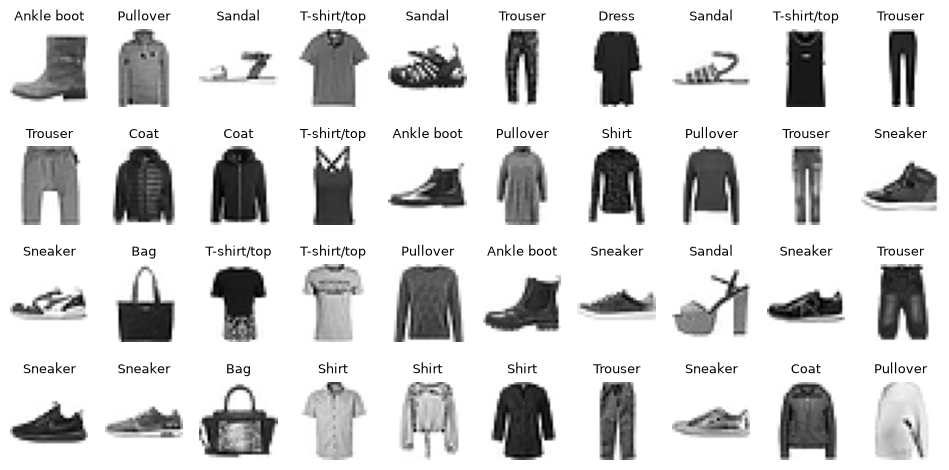

```python
# ===== Script: scripts/03_explore_data.py =====
X_sample, y_sample = train_data[0]
print("shape:", X_sample.shape, "| dtype:", X_sample.dtype,
      "| class:", class_names[y_sample])

n_rows, n_cols = 4, 10
plt.figure(figsize=(n_cols * 1.2, n_rows * 1.4))
for index in range(n_rows * n_cols):
    image, label = train_data[index]
    plt.subplot(n_rows, n_cols, index + 1)
    plt.imshow(image.squeeze(0), cmap="binary")
    plt.axis("off")
    plt.title(class_names[label], fontsize=9)
plt.subplots_adjust(wspace=0.2, hspace=0.5)
save_fig("fashion_mnist_samples", tight_layout=False)
plt.show()
```

## Cell 4 — Script `scripts/04_build_model.py`: Build the MLP classifier

Based on "Building the Classifier" in the template notebook. Requires: 01_setup.py

```python
# ===== Script: scripts/04_build_model.py =====
class ImageClassifier(nn.Module):
    def __init__(self, n_inputs, n_hidden1, n_hidden2, n_classes):
        super().__init__()
        self.mlp = nn.Sequential(
            nn.Flatten(),
            nn.Linear(n_inputs, n_hidden1),
            nn.ReLU(),
            nn.Linear(n_hidden1, n_hidden2),
            nn.ReLU(),
            nn.Linear(n_hidden2, n_classes)
        )

    def forward(self, X):
        return self.mlp(X)

torch.manual_seed(42)
model = ImageClassifier(n_inputs=1 * 28 * 28, n_hidden1=300, n_hidden2=100,
                        n_classes=10).to(device)
xentropy = nn.CrossEntropyLoss()
optimizer = torch.optim.SGD(model.parameters(), lr=0.1)
accuracy = torchmetrics.Accuracy(task="multiclass", num_classes=10).to(device)

print(model)
print("trainable parameters:",
      sum(param.numel() for param in model.parameters()))
```

```
ImageClassifier(
  (mlp): Sequential(
    (0): Flatten(start_dim=1, end_dim=-1)
    (1): Linear(in_features=784, out_features=300, bias=True)
    (2): ReLU()
    (3): Linear(in_features=300, out_features=100, bias=True)
    (4): ReLU()
    (5): Linear(in_features=100, out_features=10, bias=True)
  )
)
trainable parameters: 266610
```

## Cell 5 — Script `scripts/05_train_utils.py`: Training and evaluation helpers

Based on evaluate_tm() and train2() from the "Model Evaluation" section of the template notebook. train() records the training loss and training accuracy for every epoch (and every batch) so they can be plotted later. Requires: 01_setup.py

```python
# ===== Script: scripts/05_train_utils.py =====
def evaluate_tm(model, data_loader, metric):
    model.eval()
    metric.reset()
    with torch.no_grad():
        for X_batch, y_batch in data_loader:
            X_batch, y_batch = X_batch.to(device), y_batch.to(device)
            y_pred = model(X_batch)
            metric.update(y_pred, y_batch)
    return metric.compute()

def train(model, optimizer, criterion, metric, train_loader, valid_loader,
          n_epochs):
    history = {"train_losses": [], "train_metrics": [], "valid_metrics": [],
               "batch_train_metrics": []}
    for epoch in range(n_epochs):
        total_loss = 0.
        metric.reset()
        model.train()
        for X_batch, y_batch in train_loader:
            X_batch, y_batch = X_batch.to(device), y_batch.to(device)
            y_pred = model(X_batch)
            loss = criterion(y_pred, y_batch)
            total_loss += loss.item()
            loss.backward()
            optimizer.step()
            optimizer.zero_grad()
            batch_acc = metric(y_pred, y_batch)  # updates running state too
            history["batch_train_metrics"].append(batch_acc.item())
        mean_loss = total_loss / len(train_loader)
        history["train_losses"].append(mean_loss)
        history["train_metrics"].append(metric.compute().item())
        history["valid_metrics"].append(
            evaluate_tm(model, valid_loader, metric).item())
        print(f"Epoch {epoch + 1}/{n_epochs}, "
              f"train loss: {history['train_losses'][-1]:.4f}, "
              f"train accuracy: {history['train_metrics'][-1]:.4f}, "
              f"valid accuracy: {history['valid_metrics'][-1]:.4f}")
    return history
```

## Cell 6 — Script `scripts/06_train_model.py`: Train the model

Requires: 01-05

```python
# ===== Script: scripts/06_train_model.py =====
history = train(model, optimizer, xentropy, accuracy, train_loader,
                valid_loader, n_epochs)
```

[output not shown]

## Cell 7 — Script `scripts/07_plot_training_accuracy.py`: Plot the training accuracy

Left: training accuracy per epoch (with validation accuracy for reference). The training accuracy is averaged *during* each epoch, so it is plotted half an epoch earlier, as in the template notebook's learning curves. Right: training accuracy per batch (200-batch moving average) with the training loss per epoch on a secondary axis. Requires: 06_train_model.py

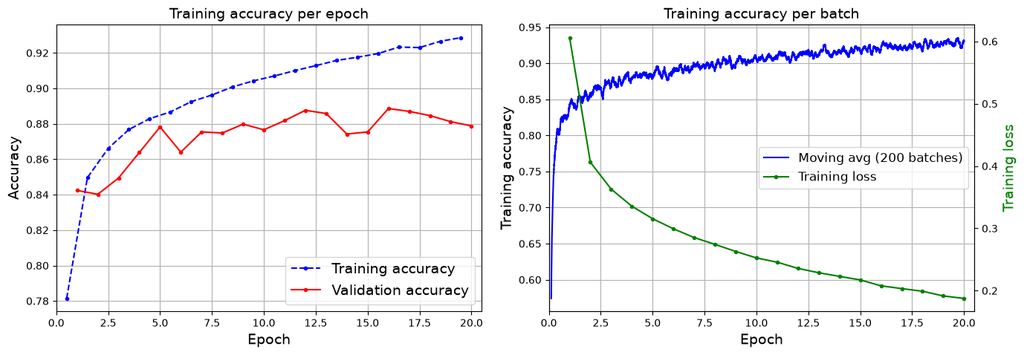

```
Final training accuracy:   0.9286
Final validation accuracy: 0.8788
```

```python
# ===== Script: scripts/07_plot_training_accuracy.py =====
epochs = np.arange(1, n_epochs + 1)
fig, (ax1, ax2) = plt.subplots(1, 2, figsize=(14, 5))

ax1.plot(epochs - 0.5, history["train_metrics"], "b.--",
         label="Training accuracy")
ax1.plot(epochs, history["valid_metrics"], "r.-",
         label="Validation accuracy")
ax1.set_xlabel("Epoch")
ax1.set_ylabel("Accuracy")
ax1.set_title("Training accuracy per epoch")
ax1.set_xlim(0, n_epochs + 0.5)
ax1.grid()
ax1.legend(loc="lower right")

batch_acc = np.array(history["batch_train_metrics"])
batches_per_epoch = len(batch_acc) / n_epochs
x_batches = np.arange(1, len(batch_acc) + 1) / batches_per_epoch
window = 200
moving_avg = np.convolve(batch_acc, np.ones(window) / window, mode="valid")
ax2.plot(x_batches[window - 1:], moving_avg, "b-",
         label=f"Moving avg ({window} batches)")
ax2.set_xlabel("Epoch")
ax2.set_ylabel("Training accuracy")
ax2.set_title("Training accuracy per batch")
ax2.set_xlim(0, n_epochs + 0.5)
ax2.grid()
ax3 = ax2.twinx()
ax3.plot(epochs, history["train_losses"], "g.-", label="Training loss")
ax3.set_ylabel("Training loss", color="g")
lines = ax2.get_legend_handles_labels()
lines3 = ax3.get_legend_handles_labels()
ax2.legend(lines[0] + lines3[0], lines[1] + lines3[1], loc="center right",
           fontsize=12)

save_fig("training_accuracy_plot")
plt.show()

print(f"Final training accuracy:   {history['train_metrics'][-1]:.4f}")
print(f"Final validation accuracy: {history['valid_metrics'][-1]:.4f}")
```

## Cell 8 — Script `scripts/08_evaluate_and_predict.py`: Evaluate on the test set and predict

Based on the prediction cells of "Building the Classifier" in the template. Requires: 06_train_model.py

```python
# ===== Script: scripts/08_evaluate_and_predict.py =====
import torch.nn.functional as F

test_acc = evaluate_tm(model, test_loader, accuracy).item()
print(f"Test accuracy: {test_acc:.4f}")

model.eval()
X_new, y_new = next(iter(valid_loader))
X_new = X_new[:3].to(device)
with torch.no_grad():
    y_pred_logits = model(X_new)
y_pred = y_pred_logits.argmax(dim=1)
y_proba = F.softmax(y_pred_logits, dim=1).cpu()

print("predicted:", [class_names[index] for index in y_pred])
print("actual:   ", [class_names[index] for index in y_new[:3]])
print("probabilities:\n", y_proba.round(decimals=3))
```

```
Test accuracy: 0.8824
predicted: ['Sneaker', 'Coat', 'Pullover']
actual:    ['Sneaker', 'Coat', 'Pullover']
probabilities:
 tensor([[0.0000, 0.0000, 0.0000, 0.0000, 0.0000, 0.0000, 0.0000, 0.8590, 0.0000,
         0.1410],
        [0.0000, 0.0000, 0.0070, 0.0000, 0.9930, 0.0000, 0.0000, 0.0000, 0.0000,
         0.0000],
        [0.0040, 0.0000, 0.5920, 0.0000, 0.2120, 0.0000, 0.1910, 0.0000, 0.0010,
         0.0000]])
```

## Cell 9 — Script `scripts/09_save_model.py`: Save and reload the model

Based on "Saving and Loading a PyTorch Model" in the template notebook. Requires: 06_train_model.py

```python
# ===== Script: scripts/09_save_model.py =====
MODEL_PATH = Path() / "models" / "fashion_mnist_mlp.pt"
MODEL_PATH.parent.mkdir(parents=True, exist_ok=True)
torch.save(model.state_dict(), MODEL_PATH)

loaded_model = ImageClassifier(n_inputs=1 * 28 * 28, n_hidden1=300,
                               n_hidden2=100, n_classes=10).to(device)
loaded_model.load_state_dict(torch.load(MODEL_PATH, weights_only=True))
loaded_acc = evaluate_tm(loaded_model, test_loader, accuracy).item()
print(f"Saved to {MODEL_PATH}; reloaded model test accuracy: {loaded_acc:.4f}")
```

```
Saved to models/fashion_mnist_mlp.pt; reloaded model test accuracy: 0.8824
```